CENES · UPTC · sábado 5 de septiembre de 2026

# Del dato crudo al pipeline

Sesión 3 · Datos — lo que el agente no escribe por usted

Antes de nada

## Hoy son 140 minutos con las manos sobre 240

35′

M1 · lo que engaña

Tres trampas reales, de trabajo propio.

50′

M3 · el agente escribe

Colab. Cada uno con su base.

30′

M5 · el reto

Tres bases, tres trampas, al azar.

25′

Recap y M2

Ampliar la carpeta y los tres escalones.

La sesión 2 arrancó haciendo y funcionó. **Hoy igual.**

El agente escribe el código en segundos.  
Lo que no escribe es la decisión de qué muestra usar.

Y esa decisión, anoche, con estos datos, dio vuelta al resultado.

R

Recap · 8:00–8:20

## Dónde estamos en la carpeta

El martes: de dónde sale una pregunta. El jueves: en qué conversación entra. Hoy: los datos.

Recap · el mapa

## Casilla 03. Todo lo anterior existía para llegar acá.

01Ideación

02Literatura

03Datos

04Análisis

05Escritura

06Comunicación

sesión 1

01 · Ideación

De dónde sale una pregunta. **Hecho el martes.**

sesión 2

02 · Literatura

En qué conversación entra. **Hecho el jueves.**

hoy

03 · Datos

Con qué se responde — y **qué se está comparando con qué**.

Al final de hoy la carpeta tiene **dos subcarpetas nuevas y un archivo que no existía.**

Recap · el puente honesto

## El caso del CAF se quedó sin datos. Y eso también es la lección.

el caso del CAF

Lo que pasó

La dirección que escogimos el jueves exigía **microdato catastral**.

No se consigue. Ni comprándolo, ni pidiéndolo con tiempo.

lo que sigue

Por qué el caso de hoy es otro

El de contratación pública, donde el dato **sí** estaba y está abierto.

Pero el que se cayó no se borra del cuaderno: **a veces la respuesta de esta etapa es que no hay con qué**, y saberlo en la semana 3 vale más que saberlo en el mes 8.

Un proyecto que se cae por falta de dato **no es un fracaso: es un hallazgo barato.**

Recap · manos, 10 minutos

## Se amplía la carpeta: dos subcarpetas y un archivo

1

Crear `04_datos/crudo/`

Aquí entra el archivo tal como lo bajó. Con su nombre original. 1 min

2

Crear `04_datos/limpio/`

Aquí sale lo que produzca el código. Nada más. 1 min

3

Crear `04_datos/FUENTES.md`

Cuatro campos: fuente · fecha de descarga · filtro aplicado · **decisión de muestra**. 5 min

4

Confirmar `03_literatura/`

Ya la tienen del jueves, con la tabla de evidencia adentro. 1 min

La plantilla está en la guía impresa. **Se llena en clase, no en la casa.**

Lo que entra a crudo/ no se toca nunca más.

Se lee, se transforma, y el resultado va a limpio/. Si hay que rehacer, se rehace desde crudo/.

M1

8:20–8:55 · 35 minutos

## Lo que se ve y lo que engaña

Primero un descriptivo que funciona. Después, tres que no.

M1 · bloque A · el descriptivo que sí funciona

## Boyacá, 2025. Y aquí ya hay una pregunta de investigación.

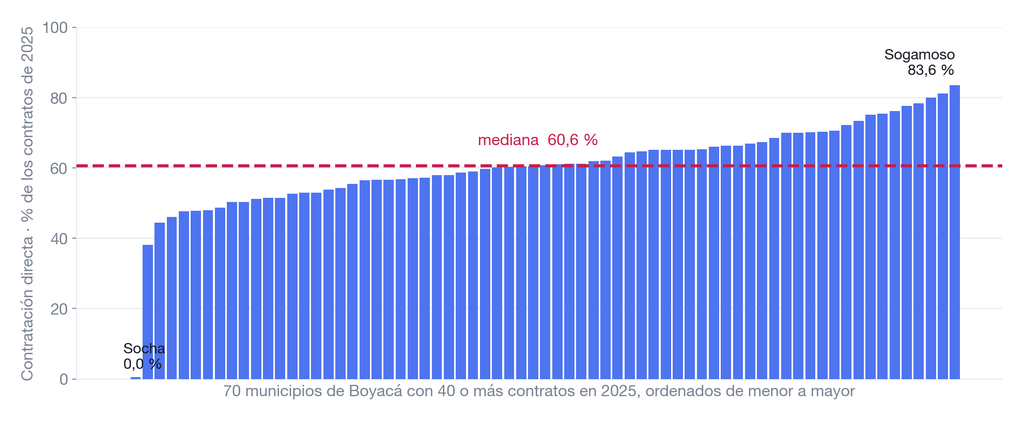

SECOP II · Contratos Electrónicos · datos.gov.co `jbjy-vk9h`, filtro Boyacá + Territorial. Descargado el 1-sep-2026. Los 70 municipios con 40 o más contratos en 2025. Contado sobre `secop_boyaca.csv`, el mismo archivo que ustedes tienen.

M1 · bloque A · lo que acaba de pasar

## Esto no es «preparar los datos». Esto ya es investigar.

cuatro líneas de código

Lo que hicimos

- Bajar un CSV.
- Agrupar por municipio.
- Dividir una columna por otra.
- Ordenar y graficar.

la pregunta

Lo que salió

Una pregunta que **no existía antes de mirar el dato**:

**¿por qué unos municipios contratan a dedo ocho de cada diez contratos y otros ninguno?**

Eso no se saca de la literatura. Se saca de mirar.

La etapa de datos **no es la antesala de la investigación. Es investigación.**

Y ahora tres veces el mismo golpe, cada vez más sutil.

Las tres son reales. Las tres son de trabajo propio. En las tres el código estaba bien.

Trampa 1 · SECOP · el salto que era la plataforma

11 → 338

contratos del municipio típico, entre 2021 y 2025

Y la contratación directa pasa del **18 % al 81 %** en el mismo período. Parece un cambio de conducta brutal.

Panel municipio–año construido desde SECOP II, 2021–2025 · `extension_electoral/resultados_did.md`. Estimaciones con efectos fijos de municipio y de año, errores agrupados por municipio.

Trampa 1 · qué era en realidad

## No cambió la conducta. Cambió quién está en la base.

| Año | Contratos del municipio típico | % por contratación directa |
| --- | --- | --- |
| 2021 | 11 | 18 % |
| 2022 | 33 | 50 % |
| 2023 | 157 | 71 % |
| 2024 | 309 | 84 % |
| 2025 | 338 | 81 % |

Un municipio que aparece con **11 contratos en 2021** y con su operación completa en 2025 no cambió de conducta: **empezó a usar SECOP II**. Lo que crece es la cobertura del instrumento, no el fenómeno.

Panel municipio–año construido desde SECOP II, 2021–2025 · `extension_electoral/resultados_did.md`. Estimaciones con efectos fijos de municipio y de año, errores agrupados por municipio.

¿Cómo lo habrían detectado? — **contando cuántos municipios hay en cada año.**

Trampa 2 · Saber 11 · el milagro educativo de 2014

## El puntaje promedio de Bogotá pasa de 47 a 255 en un año

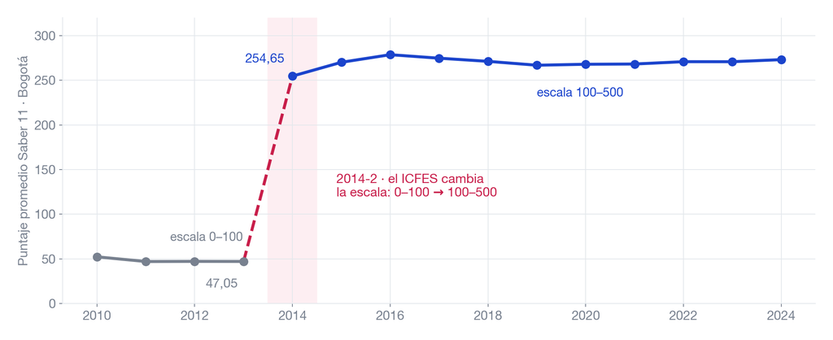

Saber 11 · microdato del ICFES agregado. Panel de **Bogotá** 2010–2024, 1.392.996 estudiante-semestres · `icfes_saber11_build_diagnostics.md`.

Trampa 2 · el detalle que la hace peor

## El corte no es en 2014. Es en 2014-2.

el instrumento

Lo que cambió

Hasta 2014-1 el puntaje era el **promedio de las materias**, en escala **0–100**.

Desde 2014-2 es un **puntaje global** en escala **100–500**.

Son dos unidades de medida distintas en la misma columna.

la mezcla

Por qué 2014 es el peor año de todos

El primer semestre de 2014 todavía es escala vieja.

Así que el promedio de 2014 **no es ni una cosa ni la otra**: es la mezcla de **6.246** estudiantes en escala vieja con **92.808** en escala nueva.

Un número que no significa nada, y que corre sin dar error.

Saber 11 · microdato del ICFES agregado. Panel de **Bogotá** 2010–2024, 1.392.996 estudiante-semestres · `icfes_saber11_build_diagnostics.md`.

¿Cómo lo habrían detectado? — **leyendo la documentación de la fuente antes de graficar.**

Trampa 3 · Saber 11 · los dos semestres

## 2021 es el mejor año de la serie. En plena pandemia.

|  | 2021-1 | 2021-2 | Qué significa la diferencia |
| --- | --- | --- | --- |
| Estudiantes | 3.278 | 80.333 | el primero es 24 veces más pequeño |
| Puntaje promedio | 324,4 | 265,9 | y 58 puntos más alto |
| % de colegio oficial | 0,5 % | 58,0 % | el primero es calendario B: casi todo privado |

Promediando los dos períodos, 2021 da **295,1** y se dispara. Pero promediar «por año» no promedia un año: **mezcla dos poblaciones**. A lo largo de la serie el segundo semestre es **17,8 veces** más grande y su promedio es **27,9 puntos** más bajo.

Saber 11 · microdato del ICFES agregado. Panel de **Bogotá** 2010–2024, 1.392.996 estudiante-semestres · `icfes_saber11_build_diagnostics.md`.

¿Cómo lo habrían detectado? — **mirando cuántas observaciones tiene cada celda.**

M1 · la regla que sale de las tres

## Antes de interpretar cualquier cambio en el tiempo: ¿qué cambió en la medición?

1

Escala

¿La unidad de medida es la misma en todo el período?

Saber 11, 2014-2.

2

Cobertura

¿Entra la misma gente a la base todos los años?

SECOP II, 368 → 717 municipios.

3

Población

¿Hay dos grupos distintos pegados en la misma columna?

Saber 11, calendario A y B.

En las tres el código estaba bien, corría y no daba error. **El error lo tomó el investigador, no la máquina.**

M2

8:55–9:25 · 30 minutos

## A mano → asistido → con sistema

El mismo ejercicio, tres veces, en vivo. Contar contratos por municipio y año.

M2 · los tres escalones

## Cada escalón le quita trabajo mecánico y le sube el listón al criterio

[figure not shown]

En el 1 uno pelea con la sintaxis. En el 2, con el prompt. **En el 3, con el criterio.**

M2 · escalón 1 · a mano

## Ocho minutos escribiendo Python delante de ustedes

con los tropiezos reales

Lo que se hace en pantalla

- Cargar el CSV y equivocarse con la ruta.
- Descubrir que `contratos` vino como texto.
- `groupby` por municipio y año.
- Dividir directa sobre total.

lo que no se automatiza

El punto que hay que dejar dicho

Emparejar municipios **por código DIVIPOLA y no por nombre** era, hace diez años, un día de trabajo.

Hoy el agente lo hace en un segundo.

Pero **decidir** que hay que emparejar por código y no por nombre —porque «Villa de Leyva» y «Villa De Leyva» son el mismo municipio y «San Luis» son cuatro— **sigue siendo del investigador**.

Lo que se automatizó fue el tiempo. **La decisión no.**

M2 · escalón 2 · asistido

## El mismo bloque, en segundos. Y se lee en voz alta.

lo que se le pide · VS Code + Claude, o CopilotCon este CSV, cuenta contratos por municipio y año  
y calcula la proporción que fue por contratación directa.  
Muéstrame el código antes de correrlo.

Y entonces la pregunta: **¿qué filas cuenta esto, y cuáles deja por fuera?**

M2 · las tres preguntas

## No hay que entenderlo línea por línea. Hay que poder contestar esto.

1

¿Sobre qué filas está calculando?

Cuál es el filtro, escrito o implícito. Un `dropna()` también es un filtro.

2

¿Qué hizo con los datos que faltan?

¿Los quitó, los rellenó, los ignoró? Las tres cosas dan resultados distintos.

3

¿Cuál es el denominador?

La mitad de los errores de proporción son un denominador que no es el que uno cree.

Si el agente no las contesta con el código en la mano, **el código no sirve todavía.**

M2 · escalón 3 · con sistema

## El script ya no lo leo. Lo que reviso es otra cosa.

el escalón 3

Lo que hay en pantalla

`panel_y_did.py`, del proyecto real. Doscientas líneas.

Construye el panel municipio–año, pega el margen electoral, estima con efectos fijos y escribe las tablas.

Corre solo, y no lo leo línea por línea.

lo único que reviso

Lo que sí reviso

**Si está mirando la muestra correcta.**

Y eso no es una frase bonita de método: **anoche esa revisión me cambió el resultado**, de «no hay efecto» a un efecto que aguanta.

Lo van a ver a las 11:10, con las dos corridas al lado.

Confío en que corre. **No confío en que esté mirando lo correcto.**

M2 · dos minutos informativos

## GitHub Copilot y Codespaces: hoy no, pero sépanlo

lo que hay

Copilot

**Gratis para estudiantes verificados** por GitHub Education: completado ilimitado y 200 créditos al mes.

lo que hay

Codespaces

Un **VS Code completo en el navegador**. Sin instalar nada, con el proyecto adentro.

**Hoy no lo usamos:** la verificación de GitHub Education tarda días. Queda como el paso siguiente.

Pausa. Diez minutos.

Al volver: cada uno abre Colab. 9:35.

M3

9:35–10:25 · 50 minutos · MANOS

## El agente escribe el código

Colab y el Data Science Agent. Gratis, sin instalar, con cuenta de Google.

M3 · fase 1 · todos juntos, 15 minutos

## Se sube el CSV y se le pide en español

tres peticiones, en este orden · Colab · Data Science AgentPerfila este archivo: cuántas filas, qué columnas,  
de qué tipo es cada una, y cuántos vacíos tiene cada columna.  
Ahora calcula la proporción de contratos que fueron por  
contratación directa, por año. Muéstrame la tabla.  
Ahora un histograma de esa proporción entre municipios, para 2023.  
Y dime cuántos municipios quedaron por fuera y por qué.

Fíjense en la tercera: **«dime cuántos quedaron por fuera y por qué».** Esa es la del curso.

M3 · fase 2 · cada uno, 35 minutos

## Con su base. O con la de Boyacá.

entregable del bloque

plan B

Si no trae datos

Está el CSV de Boyacá, que ya tienen.

Y está la lista de **fuentes abiertas colombianas** de la guía: datos.gov.co, DANE, SECOP, TerriData, Banco de la República.

Con el enlace verificado de que descarga hoy.

Se camina el salón. **La pregunta que se hace en cada puesto es siempre la misma.**

Lean el código.

No hay que entenderlo línea por línea. Hay que poder decir qué filas cuenta y cuáles deja por fuera.

Pausa. Diez minutos.

Al volver, el resultado. 10:35.

M4

10:35–11:20 · 45 minutos

## De la correlación a la causalidad

Descriptivos → correlaciones → y ahí empiezan a verse cosas → causalidad.

M4 · bloque A · la correlación que abre la puerta

## Con los datos en la mano aparece algo que no estaba en la pregunta

[figure not shown]

Una correlación no es el resultado. **Es lo que hace pensar en econometría.**

M4 · bloque B · qué hace falta para que sea causal

## La exigencia que apareció el martes: tratamiento a nivel municipio

dos callejones sin salida

El problema

«El año es 2023» **no sirve como tratamiento**: se lo come el efecto fijo de año.

Y la variable obvia —si el alcalde es reelegible— **no existe**: ningún alcalde colombiano lo es, así que vale 0 en las 2.706 filas y se absorbe entera.

el diseño que quedó

La salida

El tratamiento es la **competitividad** de la elección (1 − margen de victoria).

Lo que identifica el efecto es el **cambio** entre la administración elegida en 2019 y la de 2023. Ese corte es el «antes y después».

Panel municipio–año, efectos fijos de municipio y de año.

Panel municipio–año construido desde SECOP II, 2021–2025 · `extension_electoral/resultados_did.md`. Estimaciones con efectos fijos de municipio y de año, errores agrupados por municipio.

La variable de tratamiento obvia **no existía. Eso también es parte del trabajo.**

M4 · bloque C · el resultado

## Los que ganan apretado dirigen más valor por contratación directa

+0,275

efectos fijos

p 0,001

primeras diferencias

La misma identificación, sin dummies.

p 0,022

sin el decil superior

No lo carga un puñado de municipios.

R² 0,077

poder explicativo

Es un factor. No es *el* factor.

Panel municipio–año construido desde SECOP II, 2021–2025 · `extension_electoral/resultados_did.md`. Estimaciones con efectos fijos de municipio y de año, errores agrupados por municipio.

Se repite en número de contratos: **+0,078 · p 0,022** · magnitud **~8 puntos porcentuales**.

M4 · y los límites van en la MISMA lámina

## Lo que no se puede decir con esto

1

No es causal en sentido fuerte

Que un municipio se vuelva más competitivo no es aleatorio. Hay efectos fijos, no un experimento.

2

No es corrupción

La contratación directa es **legal**, y en muchos casos obligada por el objeto. Se mide una modalidad, no un delito.

3

No es Colombia

**146 municipios, el 13 % del país** — y los de mayor capacidad administrativa. No hay especificación que lo arregle.

Panel municipio–año construido desde SECOP II, 2021–2025 · `extension_electoral/resultados_did.md`. Estimaciones con efectos fijos de municipio y de año, errores agrupados por municipio.

Los límites no van en el pie de página ni en el apéndice. **Van al lado del número.**

M4 · el remate

## Una línea de diferencia. Dos respuestas opuestas.

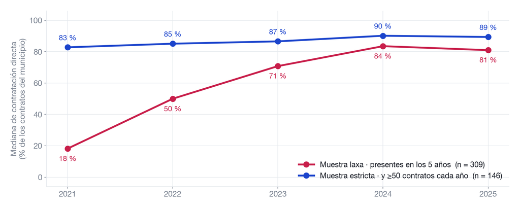

Panel municipio–año construido desde SECOP II, 2021–2025 · `extension_electoral/resultados_did.md`. Estimaciones con efectos fijos de municipio y de año, errores agrupados por municipio.

M4 · las dos corridas, en números

## La misma pregunta. El mismo código. La misma base.

|  | Muestra laxa · 309 municipios | Muestra estricta · 146 municipios |
| --- | --- | --- |
| Coef. participación directa (valor) | +0,157 | **+0,275** |
| p | 0,040 | **0,001** |
| ¿Pasa la corrección de Bonferroni? | ✗ no | ✅ sí |
| ¿Aguanta quitar el decil superior? | ✗ no · p 0,405 | ✅ sí · p 0,022 |
| En número de contratos | ✗ no significativa | ✅ +0,078 · p 0,022 |
| Veredicto | «no hay efecto» | **«hay efecto, y aguanta»** |

Panel municipio–año construido desde SECOP II, 2021–2025 · `extension_electoral/resultados_did.md`. Estimaciones con efectos fijos de municipio y de año, errores agrupados por municipio.

La lección no es que el resultado sea positivo. **Es que la definición de la muestra decidió la respuesta.**

Y solo se detecta mirando la muestra por dentro.

Ningún estadístico de bondad de ajuste se lo iba a decir. La regresión corría igual.

M5

11:20–11:50 · 30 minutos · MANOS

## El reto reproducible

Tres bases chicas, tres trampas distintas, repartidas al azar.

M5 · los tres retos

## A cada quien le toca uno. Veinte minutos.

| Reto | La base | Filas | Qué esconde |
| --- | --- | --- | --- |
| **A** | Saber 11 Bogotá, por año 2010–2024 | 15 | un cambio de escala a mitad de la serie |
| **B** | Saber 11 Bogotá, por período 2015–2024 | 20 | dos poblaciones mezcladas en la misma columna |
| **C** | SECOP II, municipios 2021–2025 | 2.706 | cobertura que crece y parece conducta |

Datos reales, de trabajo propio. **No hay nada sembrado a propósito.**

M5 · la consigna, que es la misma en los tres

## Corran el descriptivo, encuentren qué está mal, y escriban UNA línea

1

Corran el descriptivo

Lo que pide el `LEEME.md`. Nada más. Con el agente, si quieren.

2

Escriban el hallazgo en una frase

Como si fuera de un paper. En serio, escríbanlo: hace falta para el paso 3.

3

Encuentren qué la hace falsa

Hay algo en esa base que la tumba. El código no tiene ningún error.

4

Escriban su decisión de muestra

Una línea, en `FUENTES.md`. **No hay que arreglarlo: hay que detectarlo.**

A los veinte minutos **se comparan las tres respuestas.**

M5 · la casilla 03 queda con esto

## El pipeline es la descripción del método

04_datos

crudo/

Intacto. El archivo como lo bajó.

04_datos

limpio/

Lo que salió del código.

04_datos

FUENTES.md

Fuente · fecha · filtro · **decisión de muestra**.

04_datos

El cuaderno

Exportado de Colab.

Cuando escriban la sección de datos del paper, **no la van a redactar: la van a leer de acá.**

Las tres son la misma trampa.

Escala · población · cobertura. En las tres el código estaba bien y producía un número.

★

Cierre fijo · 11:50–12:00

## Una pieza de mi sistema

Hoy: el corte nocturno del ERP, que corre solo a la una de la mañana.

Cierre · el corte que falla cerrado

## Corre solo a la 1:00 a.m. Y si no puede verificar, no publica

la rutina

Qué hace

Entra al ERP, baja la ejecución del centro de costos, arma el corte y regenera los tableros.

Cuarenta minutos, sin nadie mirando.

fallar cerrado

Qué hace cuando algo no cuadra

**Nada.**

Tiene invariantes: aprobado − causado − tránsito − solicitudes tiene que dar el saldo libre. Si no da, **no escribe el tablero** y deja el error escrito.

Prefiere no decir a decir mal.

Lo que ustedes hicieron hoy a mano —decidir qué filas entran— **yo lo tengo escrito como una regla que corre sola.**

Cierre · el engranaje

## Tres casillas llenas. Faltan tres.

| Sesión | Fecha | Lo que dejó | Pieza |
| --- | --- | --- | --- |
| 01 | 1-sep | La pregunta y la carpeta | El acervo |
| 02 | 3-sep | El mapa de ramas y la tabla de evidencia | El buscador |
| 03 | 5-sep | El pipeline y la decisión de muestra | El corte del ERP |
| 04 | 8-sep | Lo que sobrevivió / lo que se descartó | — |
| 05 | 10-sep | La figura y la página | — |
| 06 | 12-sep | Las seis piezas, ensambladas en un paper | — |

Nos vemos el **martes 8 a las 6:00 p.m.** · Análisis: lo que sobrevivió y lo que se descartó.